# Bartosz Czech - Interactive Portfolio

Bartosz Czech

2026-10-30

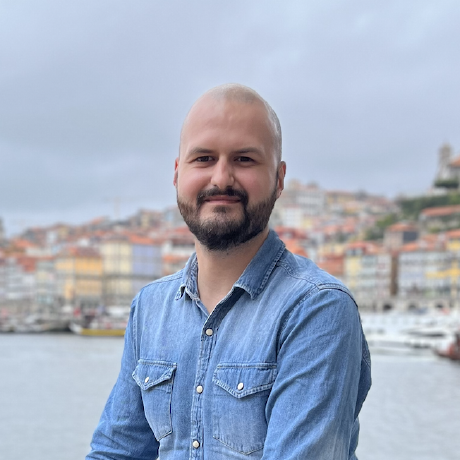

# Bartosz Czech, PhD, Eng.

### Bioinformatician & Computational Biologist

Email [LinkedIn](https://pl.linkedin.com/in/bczech) [GitHub](https://github.com/bczech) [Scholar](https://scholar.google.com/citations?user=JYaz528AAAAJ&hl=en) [ResearchGate](https://www.researchgate.net/profile/Bartosz-Czech) [ORCID](https://orcid.org/0000-0002-9908-3007) [Web of Science](https://www.webofscience.com/wos/author/record/AAZ-4115-2020) [Scopus](https://www.scopus.com/authid/detail.uri?authorId=57202362761)

100+ Citations

5 h-index

📄 Download Full CV (PDF)

# 👋 Professional Summary

I am a **Senior Bioinformatician**, **Computational Biologist**, and **R/Shiny developer** with over 7 years of experience bridging the gap between computational biology and pharmaceutical R&D. Currently at **7N**, I develop scalable **R/Shiny applications** and analyze complex NGS and MS data for a Big Pharma client.

I hold a **Ph.D. in Biological Sciences** and am currently pursuing an **MBA in Healthcare Management** (with elements of Clinical Research), combining deep technical expertise with strategic business insight.

- **Location:** Wroclaw, Poland
- **Languages:** Polish (Native), English (Upper-intermediate), Spanish (Basic)

# 🛠 Tech Stack

Programming & Dev

R Python SQL WDL Bash Git LaTeX

Data Science & ML

Statistical Modeling Machine Learning Predictive Modeling EDA Reproducible Research

Bioinformatics

NGS Data Analysis WGS & WES RNA-seq & scRNA-seq ATAC-seq 16S rRNA Variant Calling Drug Dose-Response

Genetics & Specialized

CRISPR Data Analysis Epigenomics Multi-omics Integration Microbiome Statistical Genetics Structural Biology

Visualization & Reporting

Shiny Dash ggplot2 Plotly Seaborn R Markdown Jupyter

Infrastructure & DB

AWS HPC Snowflake Docker Kubernetes Database Design FAIR Data

Agile & Workflow

Scrum Product Ownership Jira Trello

# 📦 Open Source

[figure not shown]

**ggwas** — A comprehensive ggplot2-based R package for GWAS visualization. Covers the full workflow from QC to publication — Manhattan, QQ, Miami, PheWAS, colocalization, fine-mapping, genetic correlations, and more. Journal themes, colorblind-safe palettes, and smart downsampling for biobank-scale datasets.

[figure not shown]

# 🚀 Professional Experience

### Senior Bioinformatician

**7N (Big Pharma Client)** | *July 2019 - Present* | Warsaw, Poland

**Key Responsibilities:**

- **Sequencing data:** Next-Generation Sequencing (NGS) data analysis: scRNA-seq, bulk RNA-seq, WGS, 16S rRNA sequencing.
- **Proteomics data:** Analysis of mass spectrometry (MS) data for phosphoproteomics.
- **R/Shiny Development:** Developer of interactive dashboards for data analysis.
- **Pipeline Engineering:** Maintaining production-grade WDL workflows for NGS data.

### NGS Data Analysis Internship

**Center for Quantitative Genetics and Genomics, Aarhus University** | *July - August 2018* | Foulum, Denmark

**Key Responsibilities:**

- Analysis of NGS data for quantitative genetics projects.

### Statistical Analysis Internship

**Biostat sp. z o.o. - Department of Statistics** | *July - August 2016* | Rybnik, Poland

**Key Responsibilities:**

- Statistical analysis of biological and medical data.

# 🎓 Education & Affiliations

### Education

- **Master of Business Administration (MBA)** in Healthcare Management with elements of Clinical Research | *Poznan University of Medical Sciences* (2024-Current)
- **Ph.D. in Biological Sciences** | *Wroclaw University of Environmental and Life Sciences* (2019-2024)
- **M.Sc. in Bioinformatics** (Specialization: Biostatistics and Bioinformatics Programming) | *Wroclaw University of Environmental and Life Sciences* (2017-2019)
- **B.Sc. in Bioinformatics** | *Wroclaw University of Environmental and Life Sciences* (2014-2017)

### Professional Affiliations

- **Member**, European Federation of Animal Science (2018-Present)
- **Member**, Polish Bioinformatics Society (2018-Present)

# 📚 Detailed Research Portfolio

*Click on a publication card below to reveal the specific **Bioinformatics** & **Statistics** methods used.*

**2026Motile sperm head morphometry in relation to sperm kinematics and freezability in catsTheriogenology▼**

Bioinformatics

- High-throughput data processing of single-spermatozoon kinematics and morphometry from the CASA system (>10,000 cells).
- Feature engineering for motility and morphological parameters.

Statistics

- Dimensionality reduction using **Principal Component Analysis (PCA)**.
- Unsupervised machine learning (**Clustering analysis**) to identify distinct morpho-kinetic subpopulations.
- Predictive modeling using **Classification Trees** to predict post-thaw semen quality (Good vs. Bad freezing groups).

Machine Learning Classification Trees PCA Clustering CASA Predictive Modeling

[Read Publication](https://doi.org/10.1016/j.theriogenology.2026.117839)

**2025Cooperation between the Hippo and MAPK pathway activation drives acquired resistance to TEAD inhibitionNature Communications▼**

Bioinformatics

- High-throughput screens processed with **gDR package** in R.

Statistics

- Dose-response fitting using **4-parameter logistic models**.

Drug Response Modeling R Synergy

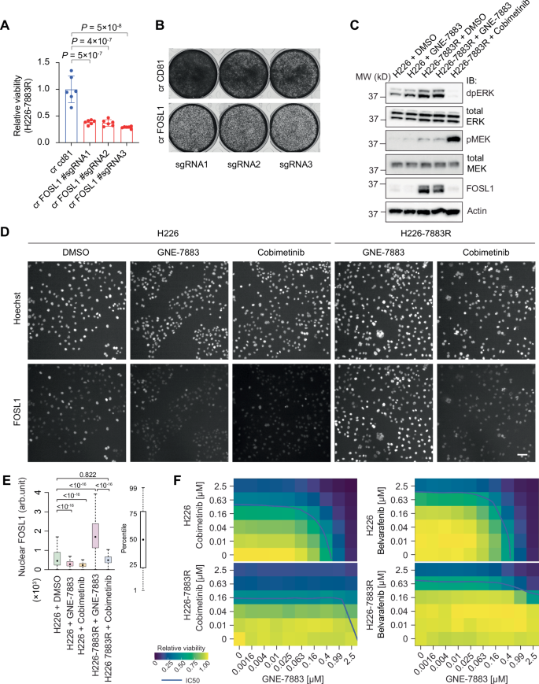

[Read Publication](https://doi.org/10.1038/s41467-025-56634-y)

**2024Profiling of snoRNAs in Exosomes Secreted from Cells Infected with Influenza A VirusInt. J. Mol. Sci.▼**

Bioinformatics

- Small RNA-seq trimmed (**Trimmomatic**) and mapped with **BWA-MEM**.
- snoRNA annotation using **Ensembl** and **Rfam**.
- Interaction predictions queried via **RNAInter** and visualized with igraph/VisNetwork.

Statistics

- Differential expression via **DESeq2** (Negative Binomial model).
- Statistical significance assessed with Wald test.
- Network enrichment determined by **hypergeometric testing**.

sRNA-seq snoRNA BWA-MEM Ensembl Rfam DESeq2

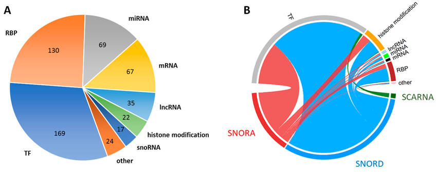

[Read Publication](https://doi.org/10.3390/ijms26010012)

**2024Computational Modeling of Drug Response Identifies Mutant-Specific Constraints for Dosing panRAF and MEK InhibitorsCancers▼**

Bioinformatics

- High-throughput screens processed with **gDR package** in R.

Statistics

- Dose-response fitting using **4-parameter logistic models**.
- Synergy scores (**Bliss Independence**) calculated.
- Significance assessed with bootstrapped confidence intervals.

Drug Response Modeling R Synergy

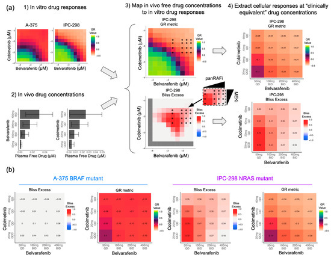

[Read Publication](https://doi.org/10.3390/cancers16162914)

**2023Feline sperm head morphometry in relation to male pedigree and fertilityTheriogenology▼**

Bioinformatics

- Data preprocessed for multivariate analysis in R.
- K-means clustering.
- Decision tree analysis.

Statistics

- **PCA** and **k-means clustering** (factoExtra) to identify subpopulations.
- Group comparisons via ANOVA (Tukey HSD) or Kruskal–Wallis.
- Shapiro-Wilk tests for normality.

PCA Clustering ANOVA R

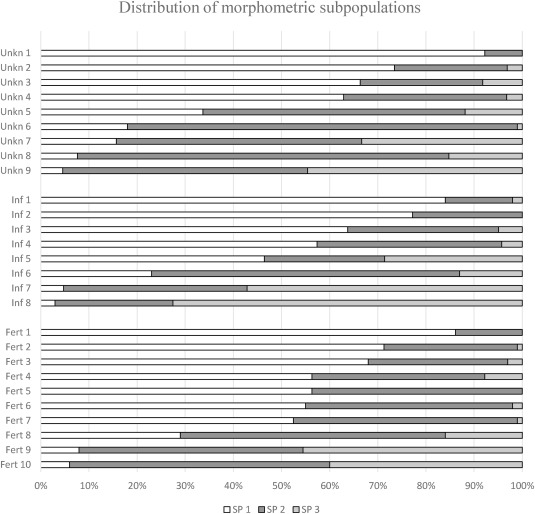

[Read Publication](https://doi.org/10.1016/j.theriogenology.2023.06.006)

**2023Protein-Coding Region Derived Small RNA in Exosomes from Influenza A Virus-Infected CellsInt. J. Mol. Sci.▼**

Bioinformatics

- Alignments to dog/flu genomes (**BWA-MEM**); annotation via Ensembl/Rfam.
- Functional annotation using **PantherDB** and **STRING** networks.

Statistics

- Differential expression assessed with **DESeq2** (Wald test, FDR).
- **Non-parametric tests** (Wilcoxon) for coverage enrichment.
- Co-expression matrices for transcript analysis.

sRNA-seq Coding RNA Alignment STRING Non-parametric Tests

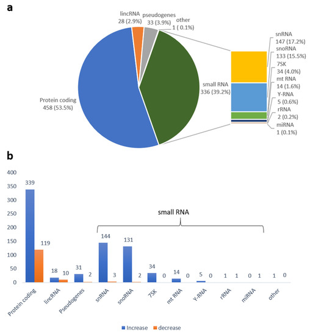

[Read Publication](https://doi.org/10.3390/ijms24010867)

**2022Host transcriptome and microbiome interactions in Holstein cattle under heat stress conditionFrontiers in Microbiology▼**

Bioinformatics

- Host RNA-seq mapped to bovine genome (**STAR**).
- 16S rRNA processed with **QIIME2/DADA2** (SILVA taxonomy).
- Integrated analysis using **WGCNA** to link gene modules and taxa.

Statistics

- Differential expression/abundance via **DESeq2**.
- **Pearson correlation** for transcriptome-microbiome integration.
- Gene set enrichment with goseq/clusterProfiler.

RNA-seq Microbiome QIIME2 WGCNA Co-expression

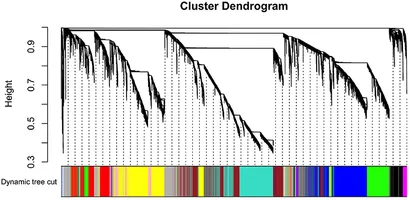

[Read Publication](https://doi.org/10.3389/fmicb.2022.998093)

**2022Fecal microbiota and their association with heat stress in Bos taurusBMC Microbiology▼**

Bioinformatics

- 16S rRNA QC (Trim Galore) and denoising (**DADA2/QIIME2**).
- Phylogenetic tree construction.

Statistics

- **Alpha/Beta diversity** metrics calculated (Shannon, Bray-Curtis).
- **PERMANOVA** for community comparison.
- Differential abundance tested using **edgeR**.
- UMAP for visualization.

QIIME2 16S rRNA Metagenomics PERMANOVA edgeR

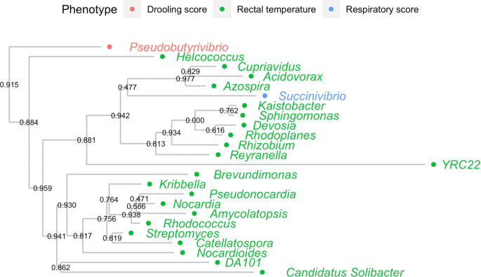

[Read Publication](https://doi.org/10.1186/s12866-022-02576-0)

**2021SNP prioritization in targeted sequencing data associated with humoral immune responses in chickenPoultry Science▼**

Bioinformatics

- Mapped to GRCg6a (**BWA-MEM**); calling with **GATK HaplotypeCaller**.
- Annotation via **Ensembl VEP**; LD analyses performed.

Statistics

- **Fisher’s Exact** and Chi-square tests for association.
- SNP prioritization model using allelic association and LD parameters.
- Mixed models for trait association.

GATK Variant Calling SNP Ensembl VEP Association Tests

[figure not shown]

[Read Publication](https://doi.org/10.1016/j.psj.2021.101433)

**2020Extraordinary Command Line: Basic Data Editing Tools for Biologists Dealing with Sequence DataThe Open Bioinformatics Journal▼**

Bioinformatics

- Demonstrated **sed, awk, grep** and **Bash scripting**.
- Workflow automation for FASTA/FASTQ/GFF files.

Statistics

N/A (Methodological Tutorial)

Linux Bash Workflow Automation Reproducibility

[Read Publication](https://doi.org/10.2174/1875036202013010137)

**2020The application of deep learning for the classification of correct and incorrect SNP genotypesJournal of Applied Genetics▼**

Bioinformatics

- Extraction of QC features (Read Depth, MapQ, Strand Bias) from BAMs.
- **Deep learning** implementation with **Keras/TensorFlow**.

Statistics

- Model evaluation using **ROC curves**, **AUC**, and confusion matrices.
- Cross-validation for generalizability assessment.

Deep Learning Keras TensorFlow Feature Engineering Python

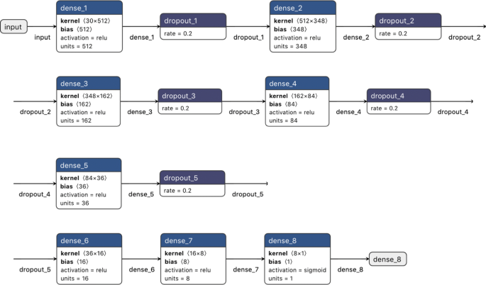

[Read Publication](https://doi.org/10.1007/s13353-020-00586-0)

**2020Patterns of DNA variation between the autosomes, the X chromosome and the Y chromosomeScientific Reports▼**

Bioinformatics

- WGS mapped (**BWA-MEM**), called via **GATK** and **SAMtools**.
- Annotation with **snpEff** and SIFT4G.

Statistics

- Diversity statistics (Tajima’s D) calculated via **VCFtools**.
- **Kruskal-Wallis** tests for chromosomal comparisons.
- Bootstrapping for CIs and Bonferroni correction.

Genomics GATK snpEff Diversity Metrics R

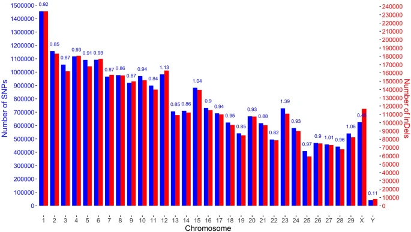

[Read Publication](https://doi.org/10.1038/s41598-020-70380-9)

**2018Identification and annotation of breed-specific single nucleotide polymorphisms in Bos taurus genomesPLOS ONE▼**

Bioinformatics

- Alignment (**BWA-MEM**), filtering (**VCFtools**, **PyVCF**), realignment (**GATK**).
- Functional analysis using **KOBAS**, OMIA, and QTLdb.

Statistics

- Overlap and enrichment analyses (Venn diagrams, gene sets).
- Descriptive analytics of population differentiation.

WGS PyVCF Ensembl VEP QTLdb Population Genetics

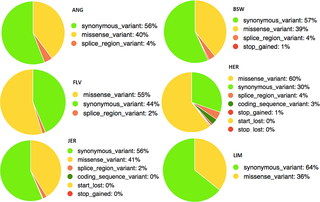

[Read Publication](https://doi.org/10.1371/journal.pone.0198419)

# 💻 Computational Skillset Showcase

## 🧬 Genomics

**Focus:** Population structure, GWAS, Variant Quality Control, and Evolution.

### Principal Component Analysis (PCA)

*Population structure visualization simulating realistic genotype noise.*

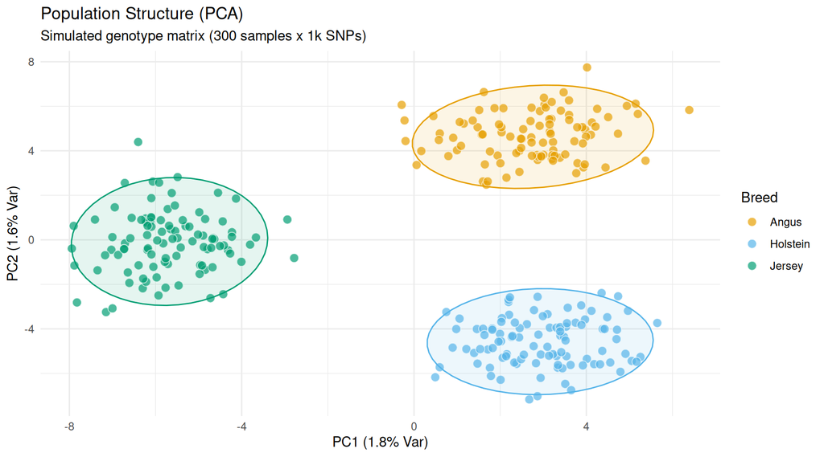

```r
# Parameters
n_samples <- 300
n_snps <- 1000

# Generate base matrix (noise)
G <- matrix(rnorm(n_samples * n_snps), nrow = n_samples)

# Define 3 populations with subtle shifts in allele frequencies
# Pop 1 (Rows 1-100): Shift in first 100 SNPs
G[1:100, 1:100] <- G[1:100, 1:100] + 0.5
# Pop 2 (Rows 101-200): Shift in SNPs 50-150
G[101:200, 50:150] <- G[101:200, 50:150] - 0.6
# Pop 3 (Rows 201-300): Shift in SNPs 800-900
G[201:300, 800:900] <- G[201:300, 800:900] + 0.7

groups <- c(rep("Holstein", 100), rep("Jersey", 100), rep("Angus", 100))

# Perform PCA
pca_res <- prcomp(G, scale. = TRUE)
var_explained <- round(summary(pca_res)$importance[2, 1:2] * 100, 1)
df_pca <- data.frame(PC1 = pca_res$x[,1], PC2 = pca_res$x[,2], Breed = groups)

ggplot(df_pca, aes(x = PC1, y = PC2, fill = Breed)) +
  geom_point(size = 3, shape = 21, color = "white", alpha = 0.7) +
  stat_ellipse(aes(color = Breed), geom = "polygon", alpha = 0.1, level = 0.95, show.legend = FALSE) +
  scale_fill_manual(values = c("#E69F00", "#56B4E9", "#009E73")) +
  scale_color_manual(values = c("#E69F00", "#56B4E9", "#009E73")) +
  theme_minimal() +
  labs(title = "Population Structure (PCA)",
       subtitle = "Simulated genotype matrix (300 samples x 1k SNPs)",
       x = paste0("PC1 (", var_explained[1], "% Var)"),
       y = paste0("PC2 (", var_explained[2], "% Var)"))
```

### Manhattan Plot (GWAS)

*Genome-Wide Association Study with LD-like signal peaks.*

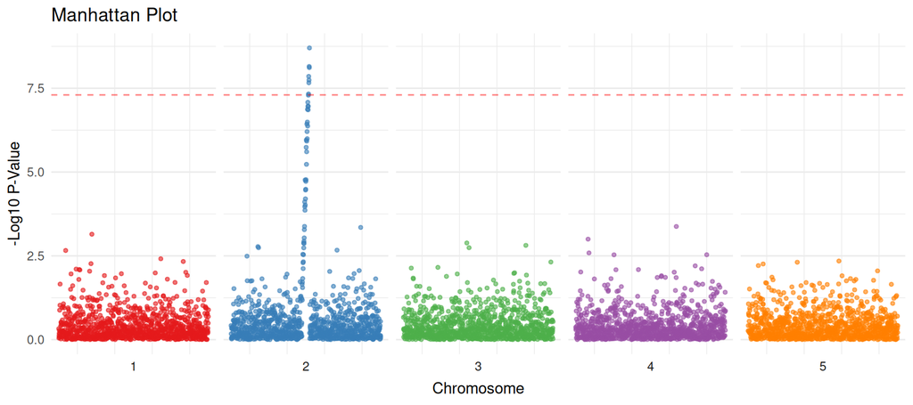

```r
n_snps <- 5000
gwas_df <- data.frame(
  SNP = paste0("rs", 1:n_snps),
  Chr = rep(1:5, each = 1000),
  Pos = rep(1:1000, 5),
  # Background noise (uniform distribution of p-values)
  PVal = runif(n_snps)
)

# Simulate Linkage Disequilibrium (LD) Peak on Chr 2
center <- 1500
width <- 50
peak_signal <- 10^-seq(1, 8, length.out = width)
gwas_df$PVal[(center-width/2):(center+width/2-1)] <- peak_signal * runif(width, 0.1, 1)

gwas_df <- gwas_df %>% mutate(logP = -log10(PVal))

ggplot(gwas_df, aes(x = Pos, y = logP, color = as.factor(Chr))) +
  geom_point(alpha = 0.6, size = 1) +
  scale_color_brewer(palette = "Set1") +
  geom_hline(yintercept = -log10(5e-8), linetype = "dashed", color = "red", alpha = 0.5) +
  theme_minimal() +
  facet_grid(. ~ Chr, scales = "free_x", space = "free_x", switch = "x") +
  theme(axis.text.x = element_blank(), panel.grid.major.x = element_blank(), legend.position = "none") +
  labs(title = "Manhattan Plot", y = "-Log10 P-Value", x = "Chromosome")
```

### Variant QC (Read Depth)

*Quality Control: Realistic skewed distribution of Read Depth.*

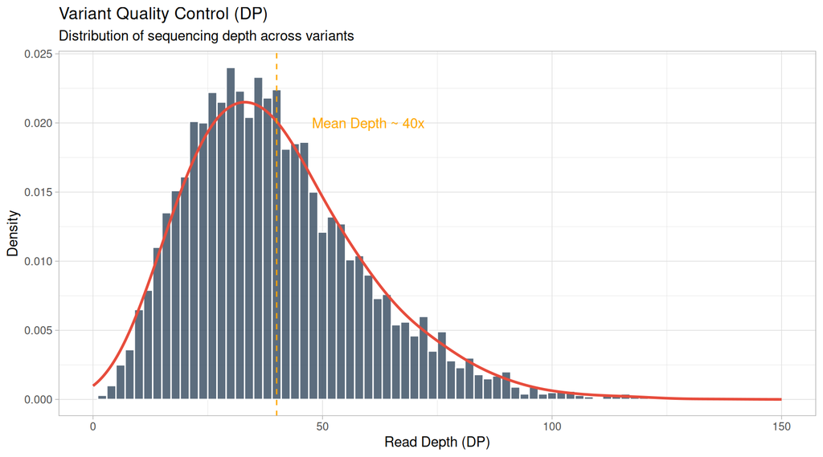

```r
# Simulate sequencing depth (Negative Binomial distribution is common for read counts)
dp_values <- rnbinom(5000, size = 5, mu = 40)

df_qc <- data.frame(Depth = dp_values)

ggplot(df_qc, aes(x = Depth)) +
  geom_histogram(aes(y = ..density..), binwidth = 2, fill = "#34495e", color = "white", alpha = 0.8) +
  geom_density(color = "#e74c3c", size = 1, adjust = 2) +
  scale_x_continuous(limits = c(0, 150)) +
  theme_light() +
  labs(title = "Variant Quality Control (DP)",
       subtitle = "Distribution of sequencing depth across variants",
       x = "Read Depth (DP)", y = "Density") +
  geom_vline(xintercept = 40, linetype="dashed", color="orange") +
  annotate("text", x = 60, y = 0.02, label = "Mean Depth ~ 40x", color = "orange")
```

### Phylogenetic Tree

*Hierarchical clustering of genetic distances.*

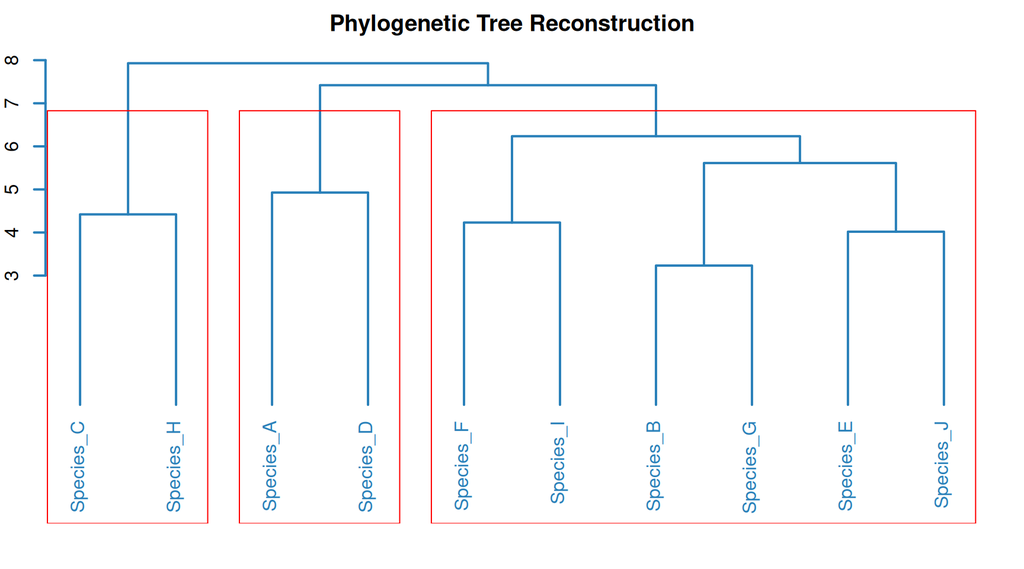

```r
# Simulate distance matrix with some structure
m <- matrix(rnorm(100), nrow = 10)
rownames(m) <- paste0("Species_", LETTERS[1:10])
dist_mat <- dist(m)
hc <- hclust(dist_mat, method = "ward.D2")

par(mar=c(2,2,2,2))
plot(hc, hang = -1, main = "Phylogenetic Tree Reconstruction",
     sub = "Ward's method clustering", xlab = "",
     col = "#2980b9", lwd = 2)
rect.hclust(hc, k = 3, border = "red") # Highlight 3 clades
```

## 🔬 Transcriptomics

**Focus:** Expression profiling, Pathways, and Single-Cell.

### Volcano Plot

*Differential Expression: Realistic relationship between Fold Change and P-value.*

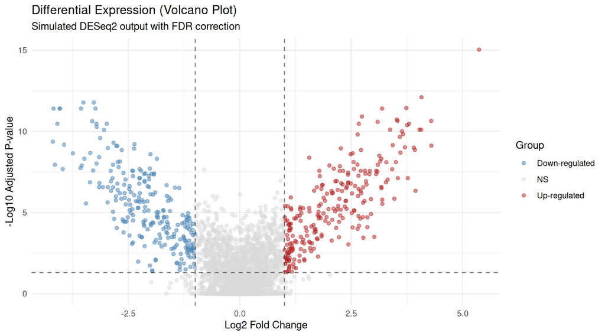

```r
n_genes <- 3000
# Generate LogFC: mostly close to 0, heavy tails
logfc <- c(rnorm(2500, 0, 0.5), rnorm(250, 2, 1), rnorm(250, -2, 1))
# Generate P-values dependent on LogFC (stronger effect -> smaller p-value)
noise <- rnorm(n_genes, 0, 2)
log_pval <- -(abs(logfc) * 3) + noise
pvals <- 10^log_pval
pvals[pvals > 1] <- 1

df_vol <- data.frame(
  Gene = paste0("G", 1:n_genes),
  log2FoldChange = logfc,
  padj = p.adjust(pvals, method = "BH")
) %>%
  mutate(
    Group = case_when(
      log2FoldChange > 1 & padj < 0.05 ~ "Up-regulated",
      log2FoldChange < -1 & padj < 0.05 ~ "Down-regulated",
      TRUE ~ "NS"
    )
  )

ggplot(df_vol, aes(x = log2FoldChange, y = -log10(padj), color = Group)) +
  geom_point(alpha = 0.5, size = 1.5) +
  scale_color_manual(values = c("steelblue", "grey85", "firebrick")) +
  geom_hline(yintercept = -log10(0.05), linetype = "dashed", alpha = 0.5) +
  geom_vline(xintercept = c(-1, 1), linetype = "dashed", alpha = 0.5) +
  theme_minimal() +
  labs(title = "Differential Expression (Volcano Plot)",
       subtitle = "Simulated DESeq2 output with FDR correction",
       x = "Log2 Fold Change", y = "-Log10 Adjusted P-value")
```

### Single-Cell UMAP

*Simulating cellular trajectories/clusters.*

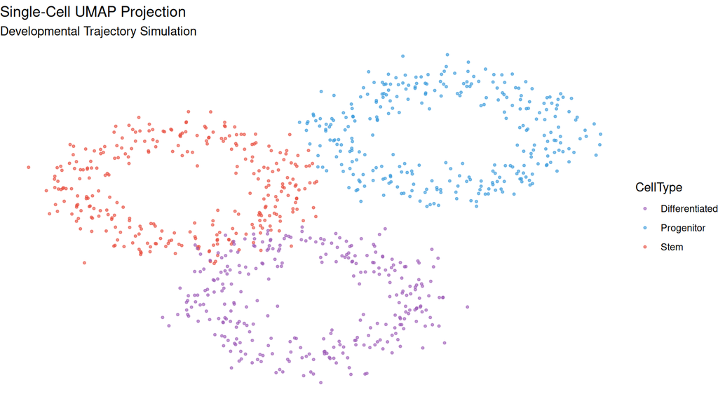

```r
# Create a "trajectory" shape rather than just blobs
t <- seq(0, 2*pi, length.out = 300)
x <- c(cos(t), cos(t) + 2.5, cos(t) + 1.2) + rnorm(900, 0, 0.2)
y <- c(sin(t), sin(t) + 1, sin(t) - 2) + rnorm(900, 0, 0.2)
clusters <- c(rep("Stem", 300), rep("Progenitor", 300), rep("Differentiated", 300))

df_umap <- data.frame(UMAP1 = x, UMAP2 = y, CellType = clusters)

ggplot(df_umap, aes(UMAP1, UMAP2, color = CellType)) +
  geom_point(size = 0.8, alpha = 0.6) +
  scale_color_manual(values = c("#9b59b6", "#3498db", "#e74c3c")) +
  theme_void() +
  theme(legend.position = "right") +
  labs(title = "Single-Cell UMAP Projection", subtitle = "Developmental Trajectory Simulation")
```

### Pathway Enrichment

*Dotplot for GSEA results.*

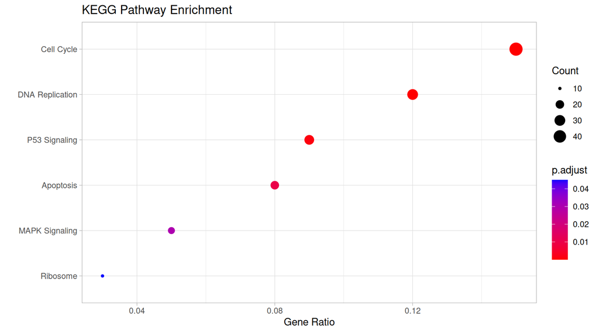

```r
df_path <- data.frame(
  Pathway = c("Cell Cycle", "DNA Replication", "P53 Signaling", "Apoptosis", "MAPK Signaling", "Ribosome"),
  Count = c(45, 30, 25, 20, 15, 10),
  GeneRatio = c(0.15, 0.12, 0.09, 0.08, 0.05, 0.03),
  p.adjust = c(1e-9, 1e-6, 0.001, 0.01, 0.03, 0.045)
)
df_path$Pathway <- factor(df_path$Pathway, levels = df_path$Pathway[order(df_path$GeneRatio)])

ggplot(df_path, aes(x = GeneRatio, y = Pathway)) +
  geom_point(aes(size = Count, color = p.adjust)) +
  scale_color_gradient(low = "red", high = "blue") +
  theme_light() +
  labs(title = "KEGG Pathway Enrichment", x = "Gene Ratio", y = "")
```

### Heatmap

*Visualizing co-expression modules.*

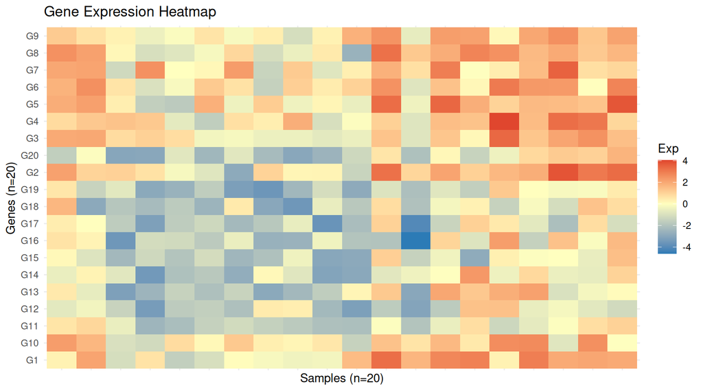

```r
# Create structured matrix
mat <- matrix(rnorm(400), nrow = 20, ncol = 20)
# Add "modules" of correlation
mat[1:10, 1:10] <- mat[1:10, 1:10] + 2
mat[11:20, 11:20] <- mat[11:20, 11:20] - 2

df_h <- as.data.frame(mat)
colnames(df_h) <- paste0("S", 1:20)
df_h$Gene <- paste0("G", 1:20)
df_h_long <- pivot_longer(df_h, cols = -Gene, names_to = "Sample", values_to = "Exp")

ggplot(df_h_long, aes(Sample, Gene, fill = Exp)) +
  geom_tile() +
  scale_fill_gradient2(low = "#2c7bb6", mid = "#ffffbf", high = "#d7191c") +
  theme_minimal() +
  theme(axis.text.x = element_blank()) +
  labs(title = "Gene Expression Heatmap", x = "Samples (n=20)", y = "Genes (n=20)")
```

### scRNA Pseudotime Trajectory

*Differentiation analysis (Monocle style).*

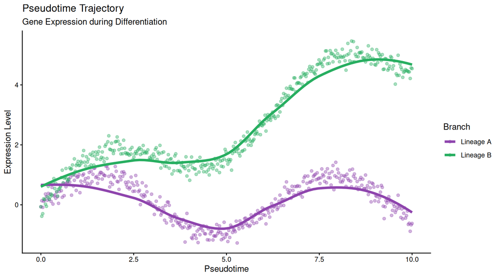

```r
set.seed(101)
t <- seq(0, 10, length.out=400)
branch1 <- data.frame(Time=t, Expr=sin(t) + rnorm(400, 0, 0.2), Branch="Lineage A")
branch2 <- data.frame(Time=t, Expr=sin(t) + 0.5*t + rnorm(400, 0, 0.2), Branch="Lineage B")
pseudo <- rbind(branch1, branch2)

ggplot(pseudo, aes(Time, Expr, color=Branch)) +
  geom_point(alpha=0.4) + geom_smooth(se=FALSE, size=1.5) +
  theme_classic() + scale_color_manual(values=c("#8e44ad", "#27ae60")) +
  labs(title="Pseudotime Trajectory", subtitle="Gene Expression during Differentiation", x="Pseudotime", y="Expression Level")
```

### DotPlot (Gene Markers)

*Expression intensity and percentage (Seurat style).*

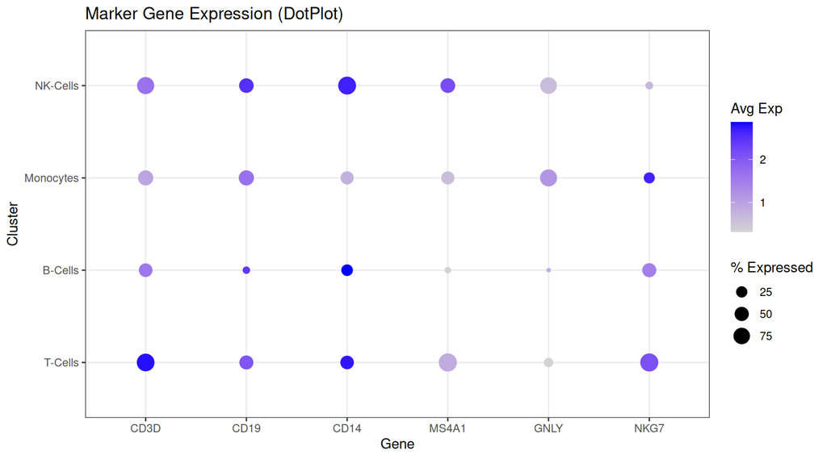

```r
genes <- c("CD3D", "CD19", "CD14", "MS4A1", "GNLY", "NKG7")
clusters <- c("T-Cells", "B-Cells", "Monocytes", "NK-Cells")
df_dot <- expand.grid(Gene=genes, Cluster=clusters)
set.seed(5)
df_dot$AvgExp <- runif(nrow(df_dot), 0, 3)
df_dot$Pct <- runif(nrow(df_dot), 0, 100)

df_dot$AvgExp[df_dot$Gene=="CD3D" & df_dot$Cluster=="T-Cells"] <- 2.8
df_dot$Pct[df_dot$Gene=="CD3D" & df_dot$Cluster=="T-Cells"] <- 90

ggplot(df_dot, aes(Gene, Cluster)) +
  geom_point(aes(size=Pct, color=AvgExp)) +
  scale_color_gradient(low="lightgrey", high="blue") +
  theme_bw() + labs(title="Marker Gene Expression (DotPlot)", size="% Expressed", color="Avg Exp")
```

## 🧪 Proteomics & Epigenomics (ATAC/Methyl)

**Focus:** Mass Spec Intensity, Motif Analysis, Chromatin Accessibility, and Methylation.

### Proteome Dynamic Range

*Rank-Abundance plot typical for Mass Spectrometry data.*

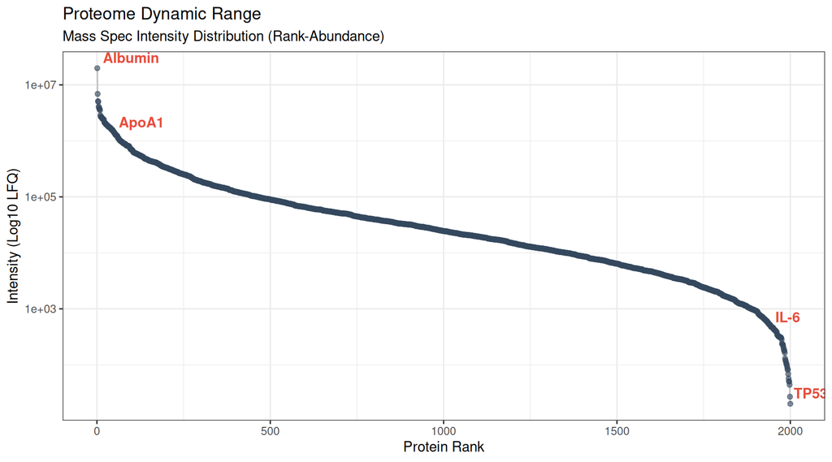

```r
n_prot <- 2000
# Simulate log-normal intensities typical for MS
intensities <- rlnorm(n_prot, meanlog = 10, sdlog = 2)
intensities <- sort(intensities, decreasing = TRUE)

df_range <- data.frame(
  Rank = 1:n_prot,
  Intensity = intensities,
  Label = NA
)

# Highlight high abundance (e.g. Albumin) and low abundance (Biomarkers)
df_range$Label[c(1, 50, 1950, 2000)] <- c("Albumin", "ApoA1", "IL-6", "TP53")

ggplot(df_range, aes(x = Rank, y = Intensity)) +
  geom_line(color = "grey", size = 0.5) +
  geom_point(alpha = 0.6, color = "#34495e") +
  scale_y_log10() +
  geom_text(aes(label = Label), vjust = -0.5, hjust = -0.1, color = "#e74c3c", fontface="bold") +
  theme_bw() +
  labs(title = "Proteome Dynamic Range",
       subtitle = "Mass Spec Intensity Distribution (Rank-Abundance)",
       x = "Protein Rank", y = "Intensity (Log10 LFQ)")
```

### Proteomics Volcano

*Differential Protein Abundance.*

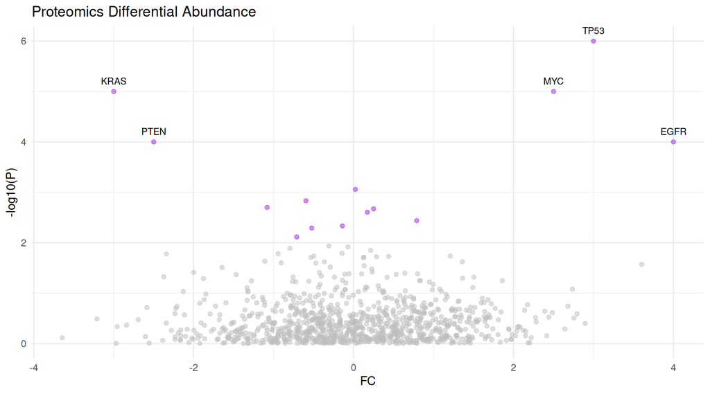

```r
df_p <- data.frame(FC=rnorm(1000), P=runif(1000))
df_p$P[1:5] <- c(1e-6, 1e-5, 1e-5, 1e-4, 1e-4); df_p$FC[1:5] <- c(3, -3, 2.5, -2.5, 4)
df_p$Label <- NA; df_p$Label[1:5] <- c("TP53", "KRAS", "MYC", "PTEN", "EGFR")

ggplot(df_p, aes(FC, -log10(P))) +
  geom_point(aes(color=P<0.01), alpha=0.5) +
  scale_color_manual(values=c("grey", "purple")) +
  geom_text(aes(label=Label), vjust=-1, size=3) +
  theme_minimal() + theme(legend.position="none") + labs(title="Proteomics Differential Abundance")
```

### Motif Sequence Logo (ATAC-seq)

```r
# NOTE: Requires 'ggseqlogo' package
if(requireNamespace("ggseqlogo", quietly=TRUE)){
  library(ggseqlogo)
  # Simulated Position Weight Matrix (PWM) for a CTCF-like motif
  # Rows: A, C, G, T; Cols: Positions
  pwm_matrix <- matrix(c(
    0.1, 0.9, 0.0, 0.0,  # Pos 1: C dominant
    0.0, 0.1, 0.0, 0.9,  # Pos 2: T dominant
    0.8, 0.1, 0.1, 0.0,  # Pos 3: A dominant
    0.9, 0.0, 0.1, 0.0,  # Pos 4: A dominant
    0.0, 0.0, 1.0, 0.0,  # Pos 5: G conserved
    0.1, 0.8, 0.1, 0.0,  # Pos 6: C dominant
    0.0, 0.0, 0.9, 0.1,  # Pos 7: G dominant
    0.0, 0.1, 0.0, 0.9   # Pos 8: T dominant
  ), nrow=4, dimnames=list(c("A","C","G","T")))

  ggseqlogo(pwm_matrix) +
    theme_minimal() +
    labs(title="Transcription Factor Motif (SeqLogo)", subtitle="Enriched in ATAC-seq peaks (CTCF-like)")
} else {
  print("Please install 'ggseqlogo' to view this plot.")
}
```

[output not shown]

```
## [1] "Please install 'ggseqlogo' to view this plot."
```

### Differential Methylation

*Volcano plot for CpG sites.*

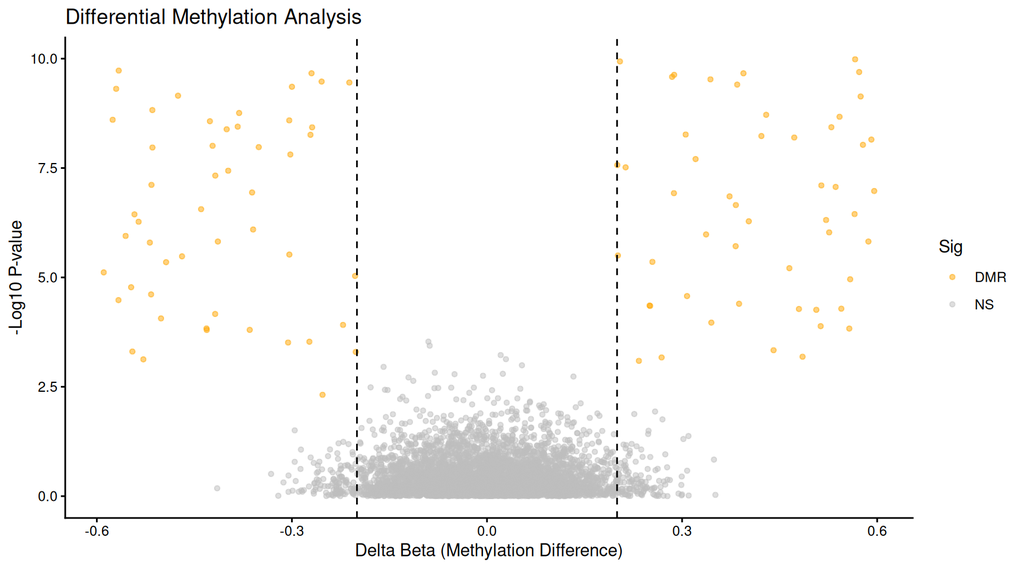

```r
# Simulate Delta Beta values (-1 to 1)
delta_beta <- rnorm(5000, 0, 0.1)
# Add some hyper/hypo methylated sites
delta_beta[1:50] <- runif(50, 0.2, 0.6)
delta_beta[51:100] <- runif(50, -0.6, -0.2)
pvals <- runif(5000)
pvals[1:100] <- 10^-runif(100, 3, 10) # Significant

df_meth <- data.frame(DeltaBeta=delta_beta, P=pvals)
df_meth$Sig <- ifelse(df_meth$P < 0.01 & abs(df_meth$DeltaBeta) > 0.2, "DMR", "NS")

ggplot(df_meth, aes(DeltaBeta, -log10(P), color=Sig)) +
  geom_point(alpha=0.5, size=1.2) +
  scale_color_manual(values=c("orange", "grey")) +
  geom_vline(xintercept=c(-0.2, 0.2), linetype="dashed") +
  theme_classic() +
  labs(title="Differential Methylation Analysis", x="Delta Beta (Methylation Difference)", y="-Log10 P-value")
```

### TSS Enrichment Profile

*Chromatin accessibility around Transcription Start Sites.*

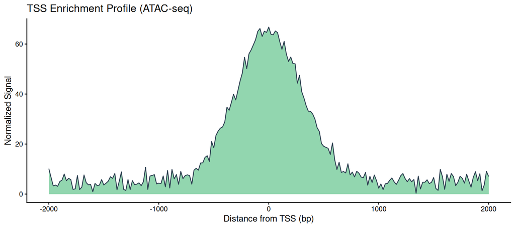

```r
x <- seq(-2000, 2000, 20)
# Gaussian peak for accessible chromatin
y <- 60 * exp(-x^2 / (2*300^2)) + rnorm(length(x), 5, 2)

ggplot(data.frame(x,y), aes(x,y)) +
  geom_area(fill="#27ae60", alpha=0.5) +
  geom_line(color="#2c3e50") +
  theme_classic() +
  labs(title="TSS Enrichment Profile (ATAC-seq)", x="Distance from TSS (bp)", y="Normalized Signal")
```

### Chromatin States

*ChromHMM style heatmap.*

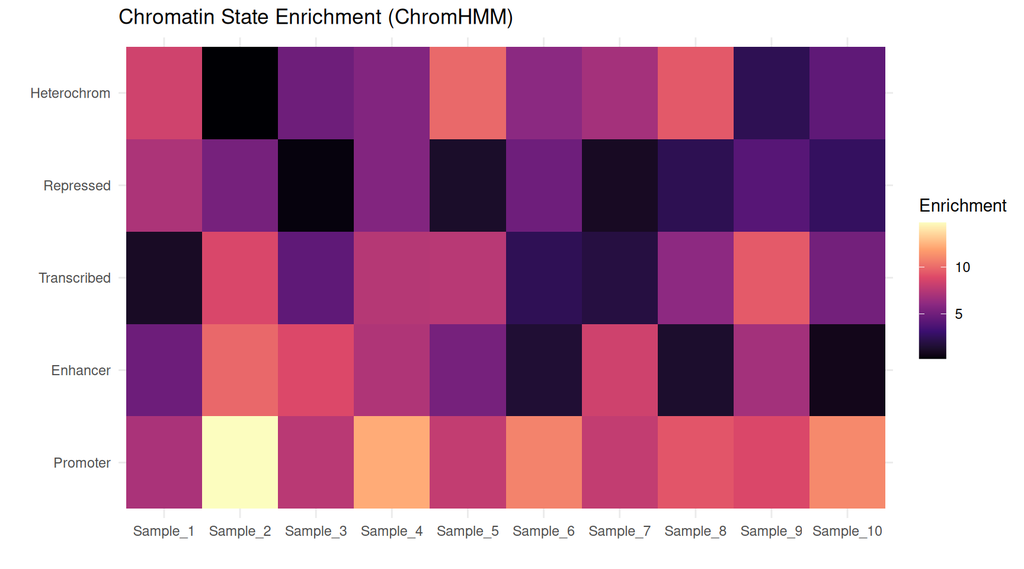

```r
states <- c("Promoter", "Enhancer", "Transcribed", "Repressed", "Heterochrom")
samples <- paste0("Sample_", 1:10)
df_chrom <- expand.grid(State=states, Sample=samples)
df_chrom$Enrichment <- runif(50, 0, 10)
df_chrom$Enrichment[df_chrom$State=="Promoter"] <- df_chrom$Enrichment[df_chrom$State=="Promoter"] + 5

ggplot(df_chrom, aes(Sample, State, fill=Enrichment)) +
  geom_tile() +
  scale_fill_viridis_c(option="magma") +
  theme_minimal() +
  labs(title="Chromatin State Enrichment (ChromHMM)", x="", y="")
```

## 💊 Pharma & CRISPR & ML

**Focus:** Drug Discovery, CRISPR Screens, and Machine Learning.

### CRISPR Gene Rank Plot

*Genome-wide ranking of gene essentiality (MAGeCK style).*

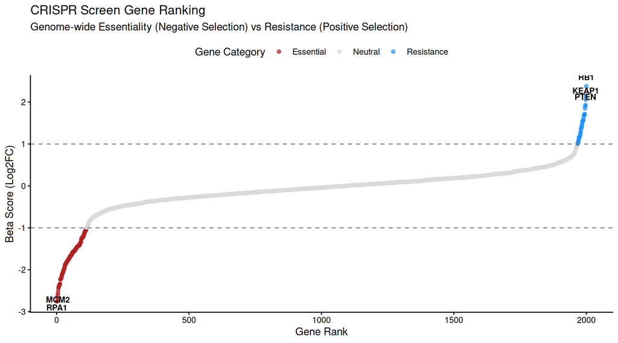

```r
n_genes <- 2000

scores <- c(rnorm(1800, mean = 0, sd = 0.3),
            rnorm(150, mean = -1.5, sd = 0.6),
            rnorm(50, mean = 1.2, sd = 0.5))

df_rank <- data.frame(Score = scores)
df_rank <- df_rank[order(df_rank$Score), , drop = FALSE]
df_rank$Rank <- 1:nrow(df_rank)

df_rank$Type <- "Neutral"
df_rank$Type[df_rank$Score < -1] <- "Essential"
df_rank$Type[df_rank$Score > 1] <- "Resistance"

df_rank$Label <- NA
df_rank$Label[1:5] <- c("RPA1", "PCNA", "POLR2A", "MYC", "MCM2")
n <- nrow(df_rank)
df_rank$Label[(n-4):n] <- c("PTEN", "NF1", "KEAP1", "TP53", "RB1")

ggplot(df_rank, aes(x = Rank, y = Score, color = Type)) +
  geom_point(size = 1.5, alpha = 0.7) +
  scale_color_manual(values = c("firebrick", "grey85", "dodgerblue")) +
  geom_text(aes(label = Label), vjust = ifelse(df_rank$Score > 0, -1, 1.5),
            size = 3, fontface = "bold", color = "black", check_overlap = TRUE) +
  geom_hline(yintercept = c(-1, 1), linetype = "dashed", color = "grey50") +
  theme_classic() +
  labs(title = "CRISPR Screen Gene Ranking",
       subtitle = "Genome-wide Essentiality (Negative Selection) vs Resistance (Positive Selection)",
       x = "Gene Rank",
       y = "Beta Score (Log2FC)",
       color = "Gene Category") +
  theme(legend.position = "top")
```

### Feature Importance (RF)

*Biomarker discovery.*

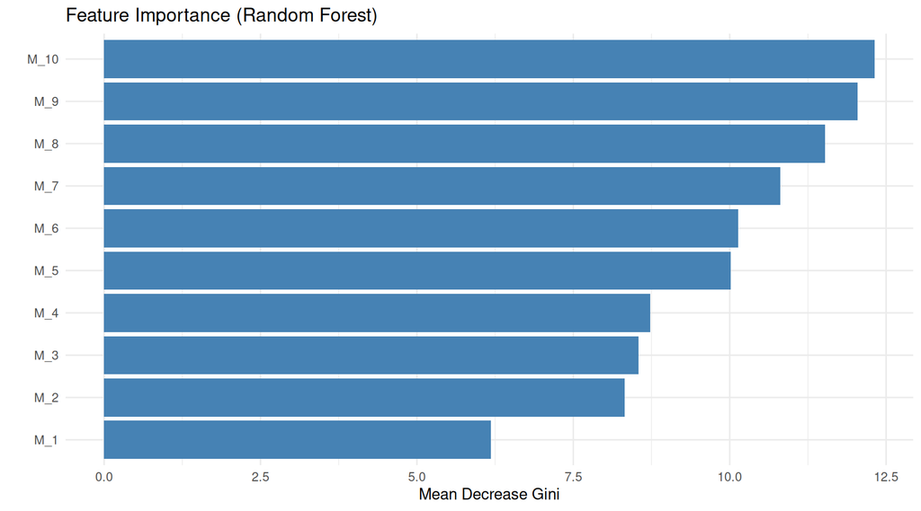

```r
imp <- data.frame(Feat=paste0("M_", 1:10), Val=sort(rnorm(10, 10, 2)))
ggplot(imp, aes(reorder(Feat, Val), Val)) + geom_col(fill="steelblue") + coord_flip() +
  theme_minimal() + labs(title="Feature Importance (Random Forest)", x="", y="Mean Decrease Gini")
```

### Dose-Response (S-Curve)

*Pharmacodynamics using 4-Parameter Logistic Model.*

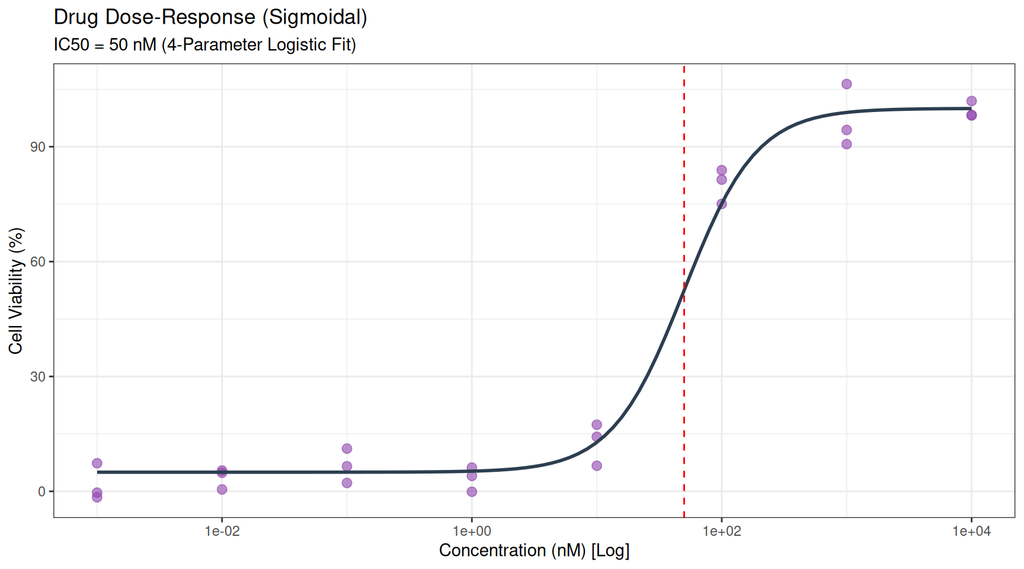

```r
# Define 4-Parameter Logistic Function
f_4pl <- function(x, b, c, d, e) { c + (d - c) / (1 + exp(b * (log(x) - log(e)))) }

concs <- c(0.001, 0.01, 0.1, 1, 10, 100, 1000, 10000)
# Parameters: b=Slope, c=Bottom, d=Top, e=IC50
true_y <- f_4pl(concs, b = -1.5, c = 5, d = 100, e = 50)

# Add biological replicates and noise
df_dr <- data.frame(
  Conc = rep(concs, each=3)
)
df_dr$Resp <- rep(true_y, each=3) + rnorm(nrow(df_dr), 0, 5) # Noise

ggplot(df_dr, aes(x=Conc, y=Resp)) +
  geom_point(size=2.5, alpha=0.6, color="#8e44ad") +
  geom_function(fun = function(x) f_4pl(x, -1.5, 5, 100, 50), color="#2c3e50", size=1) +
  scale_x_log10() +
  theme_bw() +
  labs(title="Drug Dose-Response (Sigmoidal)",
       subtitle="IC50 = 50 nM (4-Parameter Logistic Fit)",
       x="Concentration (nM) [Log]", y="Cell Viability (%)") +
  geom_vline(xintercept=50, linetype="dashed", color="red")
```

### ROC Curve (Classification)

*Model performance metrics.*

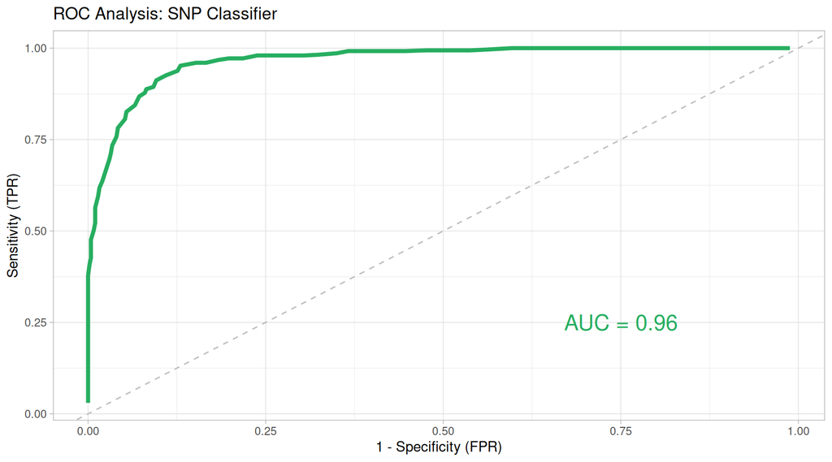

```r
# Simulate scores for Positive and Negative classes
neg_scores <- rnorm(500, mean=0.3, sd=0.15)
pos_scores <- rnorm(500, mean=0.7, sd=0.15) # Better separation

# Calculate ROC points manually
thresholds <- seq(0, 1, 0.01)
tpr <- sapply(thresholds, function(t) mean(pos_scores > t))
fpr <- sapply(thresholds, function(t) mean(neg_scores > t))

df_roc <- data.frame(FPR=fpr, TPR=tpr)

ggplot(df_roc, aes(x=FPR, y=TPR)) +
  geom_path(color="#27ae60", size=1.5) +
  geom_abline(linetype="dashed", color="grey") +
  theme_light() +
  annotate("text", x=0.75, y=0.25, label="AUC = 0.96", size=6, color="#27ae60") +
  labs(title="ROC Analysis: SNP Classifier", x="1 - Specificity (FPR)", y="Sensitivity (TPR)")
```